# Python基础 :数据文件的导入导出

# 五、tushare股票数据平台的数据加载

## （一）tushare安装与使用说明

1，TuShare的安装：pip install tushare 2，如果是老版本升级，可以用升级命令pip install tushare --upgrade 3，在python中导入包：import tushare as ts

python stock数据包tushare的使用指南  
http://www.361way.com/python-stock-tushare/4579.html

tushare官网(旧版)  
http://tushare.org/trading.html#id2

Tushare Pro版:https://tushare.pro/document/2  
下载安装：https://tushare.pro/document/1?doc_id=7  
注册TUSHARE社区用户：https://tushare.pro/document/1?doc_id=38

Tushare Pro教程：股票基本数据接口  
https://blog.csdn.net/weixin_43780423/article/details/84403938

## （二）tushare股票数据调取示例

```python
import pandas as pd
import tushare as ts
print(ts.__version__) #查看当前版本
```

[output not shown]

```python
ts.set_token('62ba54ab2804c493a21c1171f43e906b827527ec1962619c66b679cc')   #设置token，只需设置一次
api = ts.pro_api()#初始化接口
```

```python
# 日线行情接口daily，获取前复权价
df = api.daily(ts_code='603993.SH',start_date='20180101',end_date='20220329')
df
```

[output not shown]

```python
df.to_excel(r"603993.xlsx")
```

```python
df = api.daily(trade_date='20220328')
df
```

[output not shown]

```python
df.to_csv('20220328.csv')
```

```python
import tushare as ts

#获取股票1分钟数据
df = ts.pro_bar(ts_code='600000.SH',
                    freq='1min',
                    start_date='2020-01-07 09:00:00',
                    end_date='2020-01-08 17:00:00')

print(df)
```

[output not shown]

```python
#获取指数分钟数据
df = ts.pro_bar(ts_code='000001.SH',
                    asset='I',
                    freq='1min',
                    start_date='2020-01-07 09:00:00',
                    end_date='2020-01-08 17:00:00')

print(df)
```

[output not shown]

```python
#获取基金1分钟数据
df = ts.pro_bar(ts_code='150018.SZ',
                    asset='FD',
                    freq='1min',
                    start_date='2020-01-07 09:00:00',
                    end_date='2020-01-08 17:00:00')
```

```python
#获取数字货币分钟数据
df = pro.coin_mins(symbol='btcusdt',
                    exchange='huobi',
                    freq='1min',
                    trade_date='20200107')

print(df)
```

[output not shown]

## (三)从tushare调取沪深300指数数据

```python
df_hs300_1 = ts.get_hist_data('hs300',start='2021-01-01',end='2021-12-31')
df_hs300_1
```

[output not shown]

```python
df_hs300_2 = ts.get_hist_data('hs300',start='2020-01-01',end='2020-12-31')
df_hs300_2
```

[output not shown]

```python
df_hs300_1.to_csv(r'hs300.csv')
```

# 六、网页爬虫获取数据

```python
import pandas as pd
pd.options.display.float_format='{:,2f}'.format
import matplotlib.pyplot as plt
plt.rcParams['font.family']='SimHei'
plt.rcParams['axes.unicode_minus']=False
```

## （一）爬取PC、服务器及硬件行业上市公司的股票代码、股票名称，并以DataFrame展示

```python
stockcodes=list()
company_names=list()
table=pd.read_html('https://s.askci.com/stock/a-ci0000001795-0/1')[0]
sr=table['股票代码']
company_names=company_names+table['股票名称'].tolist()
for i,v in sr.items():  #对小于6位的股票代码前面补0
    digit_no=len(str(v))
    s=''
    for j in range(6-digit_no):
        s=s+'0'
    s=s+str(v)
    stockcodes.append(s)
#以dataFrame形式来展示获取的股票代码和股票名称
ls=list()
ls.append(stockcodes)
ls.append(company_names)
df_company=pd.DataFrame(ls)
df_company
company_names
stockcodes
```

[output not shown]

```python
#查看指定股票代码(002415)的网页信息显示
tables=pd.read_html('https://s.askci.com/stock/financialanalysis/'+'002415'+'/',header=None,index_col=None)
print(tables)
```

[output not shown]

```python
print(tables[1]) #显示成本费用分析表
```

[output not shown]

# 七、CSMAR数据库数据的导入

## （一）安装CSMAR-PYTHON

1. 安装python3.6.X工具【压缩包】，并安装类库urllib3，websocket，websocket_client，pandas pip install urllib3 pip install websocket pip install websocket_client pip install pandas
2. CSMAR-PYTHON安装方式 下载CSMAR-PYTHON【压缩包】 解压至python安装目录下的\Lib\site-packages 如:\Programs\Python36\Lib\site-packages

系统中所有的函数返回数据格式默认都是json，可以通过列表打印类库(prettytable)来格式化数据以便查看 pip install prettytable

确定当前Python环境中的site-packages目录位置

python -m site

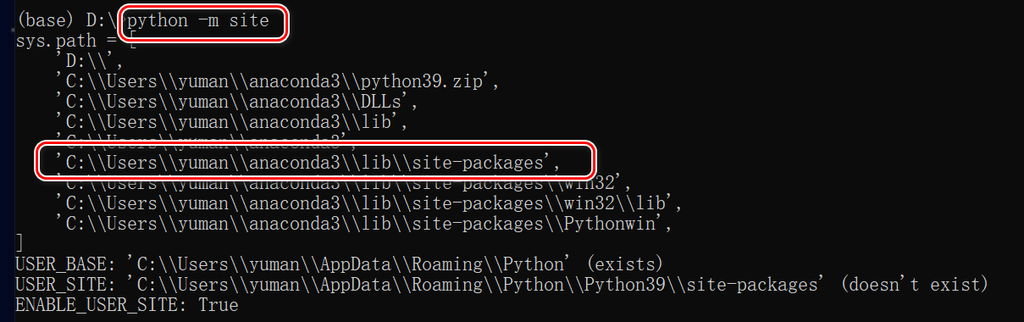

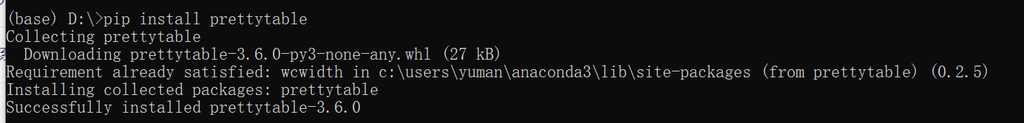

## （二）使用CSMAR-PYTHON

```python
from csmarapi.CsmarService import CsmarService
csmar = CsmarService()
```

```python
login(account,pwd,lang)
```